# Part II - Use of Bikes From Ford GoBike Sharing System

## by Hichem Dridi

## Investigation Overview

In this investigation, I did a descriptive analysis on the journeys made by the bikes of the Ford GoBike Sharing System. Emphasis was placed on the effect of days and times of the week on bicycle use and travel times.

## Dataset Overview

The original dataset we started with contains information on 183,412 bike trips divided into 16 different columns that describe trip time, stations, date, user, and more. With some cleanup and feature engineering, that number of columns grew to 22, I've only kept 14 for the analysis part.

## Users of the Bike Sharing System

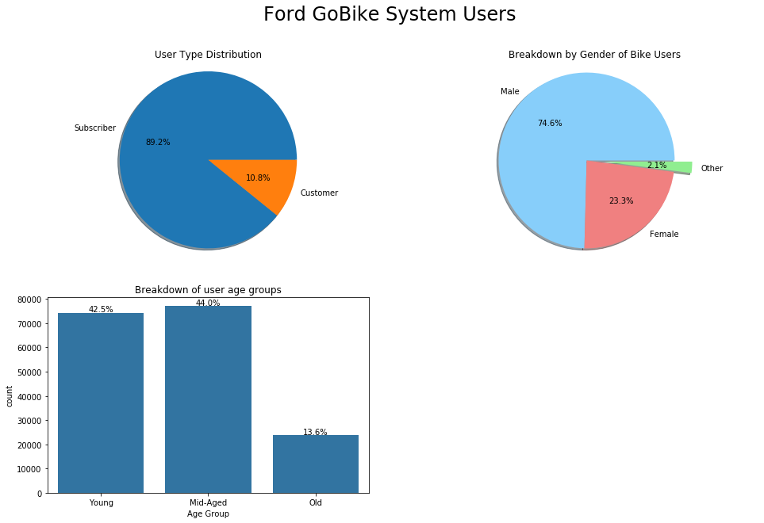

## The Stations

The data was collected during the month of February in the San Francisco Bay Area, the stations are distributed in the cities of San Francisco, Berkeley, Oakland, Emeryville, San Jose and Piedmont.

Make this Notebook Trusted to load map: File -> Trust Notebook

[interactive chart not shown]

Among the cities mentioned above, San Francisco is the city with the highest number of bicycles used during this period:

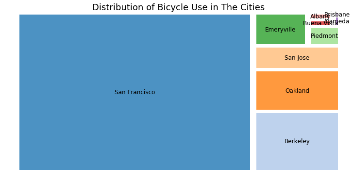

## Distribution of Trips Duration

The duration of trips in the dataset takes a very wide range of values, from about a minute to almost a day. Plotted on a logarithmic scale, the distribution of bike rides duration appears normal with a peak around 10 minutes.

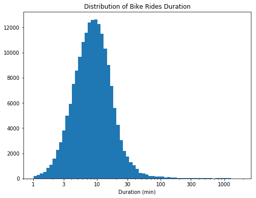

## The Effect of Day and Time

I was interested in the evolution of hourly and daily bicycle use. Weekdays and times when people tend to commute from home to work and vice versa had the highest use of bicycles. On the other side, weekeends have the greatest average bike rides duration, especially in the middle of the day.

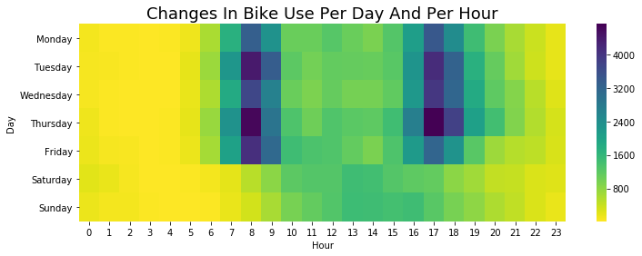

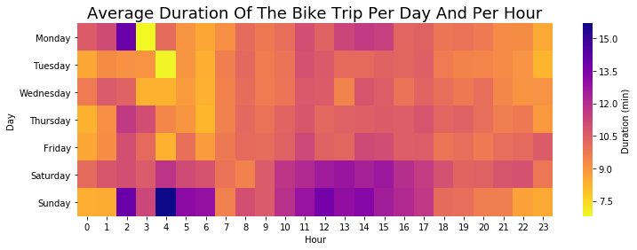

## Who Rides The Longest?

With only three user-related features to investigate, the trend I found is that customers tend to cycle for longer periods of time than subscribers. In contrast, men tend to make shorter journeys in all three age categories.

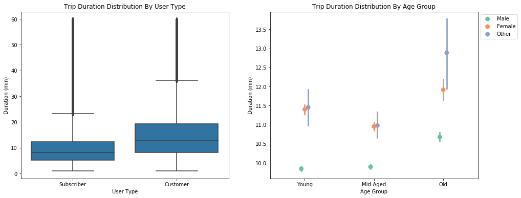